# Statistiek - Lab session 4

J.F.P. (Richard) (s2956586)

Generated on: Tue Mar 27 13:55:44 2018

# 1 Exercise 1

```r
download.file('http://www.let.rug.nl/wieling/Statistiek-I/dat.rda','dat.rda')
load('dat.rda',verbose=T)
```

```
## Loading objects:
##   dat
```

```r
str(dat)
```

```
## 'data.frame':    315 obs. of  18 variables:
##  $ participant         : int  1 2 3 4 5 6 7 8 9 10 ...
##  $ year                : num  2017 2017 2017 2017 2017 ...
##  $ study               : Factor w/ 4 levels "CIS","IS","LING",..: 3 3 3 1 3 3 3 3 3 2 ...
##  $ edu_level           : Factor w/ 3 levels "HAVO","VWO","HBO": 2 NA 2 3 1 2 2 2 2 2 ...
##  $ gender              : Factor w/ 2 levels "F","M": 1 2 2 1 1 1 1 1 1 2 ...
##  $ hand                : Factor w/ 2 levels "R","L": 1 1 1 1 1 1 1 1 1 1 ...
##  $ instrument          : Factor w/ 2 levels "Y","N": 1 2 1 2 2 1 2 2 1 1 ...
##  $ bl_edu              : Factor w/ 2 levels "Y","N": 2 2 2 2 2 2 2 1 2 2 ...
##  $ l1cnt               : num  1 1 1 1 1 1 1 1 1 1 ...
##  $ l2cnt               : num  3 1 2 1 2 3 1 3 1 2 ...
##  $ age_listening       : num  11 11 9 10 11 11 11 9 6 7 ...
##  $ age_reading         : num  10 11 9 10 11 11 11 9 11 7 ...
##  $ age_speaking        : num  10 11 9 10 11 11 12 10 11 7 ...
##  $ age_writing         : num  11 13 9 10 12 11 12 10 11 7 ...
##  $ accent_strength_self: num  8 3 5 7 9 6 4 4 5 4 ...
##  $ english_grade       : num  6 7 8 7 7 8 7 8 6 8 ...
##  $ english_score_self  : num  4 9.5 8.25 7.25 6.75 7.75 7.5 7.75 6.5 9 ...
##  $ english_score       : num  4.31 6.42 8.17 6.99 6.12 ...
```

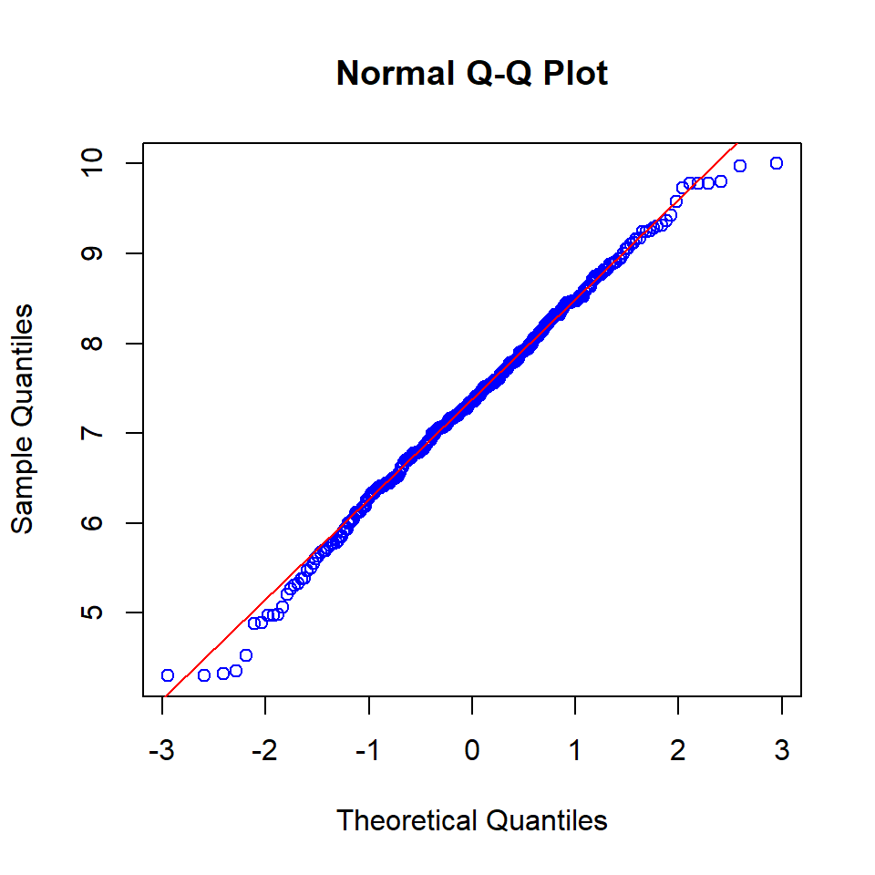

```r
set.seed(111)
qqnorm(dat$english_score, col="blue")
qqline(dat$english_score, col="red")
```

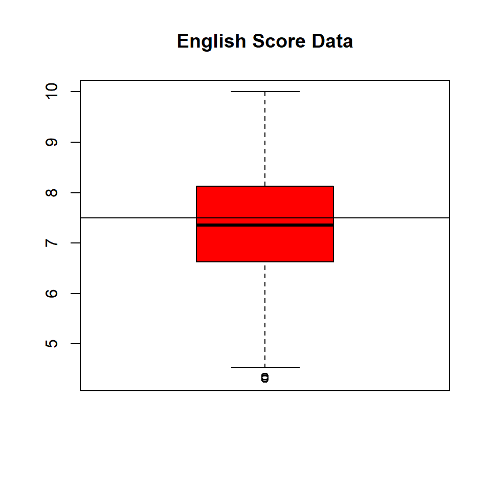

```r
boxplot(dat$english_score, main="English Score Data", col="red")
abline(h=7.5)
```

```r
t.test(dat$english_score, alternative = "less", mu= 7.5 )
```

```
##
##  One Sample t-test
##
## data:  dat$english_score
## t = -2.3935, df = 314, p-value = 0.008638
## alternative hypothesis: true mean is less than 7.5
## 95 percent confidence interval:
##      -Inf 7.452458
## sample estimates:
## mean of x
##  7.347009
```

t(314) = -2.39, p =0.009

H0: $\mu$d = $\mu$t and Ha: $\mu$d < $\mu$t

We obtained English scores in a sample of 315 students of the Statistiek 1 course via an online questionnaire.

There are 315 samples obtained through the students. Therefor there are more than 30 values and normally distributed which means the t-test could be used.

Mean of the english: 7.347 Significance level: 0.05 t(314) = -2.39 p = 0.009

The alternative hypothesis can be accepted. This means that the average english_score of the students is lower than 7.5

# 2 Exercise 2

```r
t.test(dat$english_score, alternative = "two.sided", mu= 7.5 )
```

```
##
##  One Sample t-test
##
## data:  dat$english_score
## t = -2.3935, df = 314, p-value = 0.01728
## alternative hypothesis: true mean is not equal to 7.5
## 95 percent confidence interval:
##  7.221245 7.472773
## sample estimates:
## mean of x
##  7.347009
```

The results are significant because the p-level is below the significance level. Therefor H0 is rejected and we accept Ha.

H0: $\mu$d = $\mu$t Ha: $\mu$d $\neq$ $\mu$t

# 3 Exercise 3

```r
table(dat$gender)
```

```
##
##   F   M
## 222  93
```

```r
datF <- dat[dat$gender == "F", ]
datM <- dat[dat$gender == "M", ]
mean(datF$english_score)
```

```
## [1] 7.203624
```

```r
mean(datM$english_score)
```

```
## [1] 7.689283
```

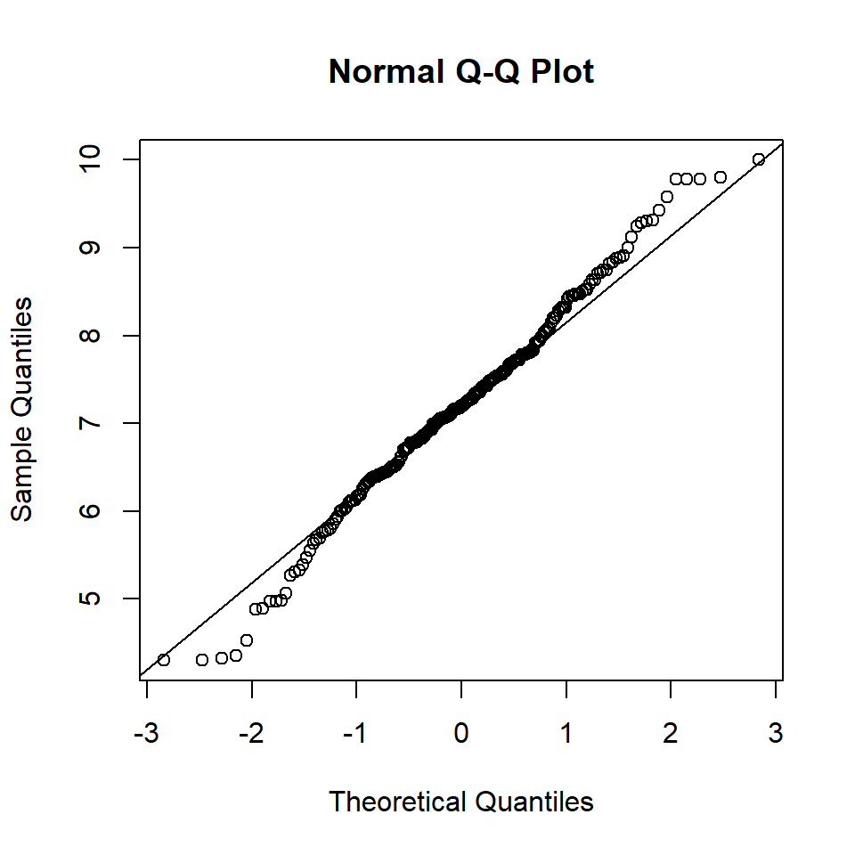

```r
qqnorm(datF$english_score)
qqline(datF$english_score)
```

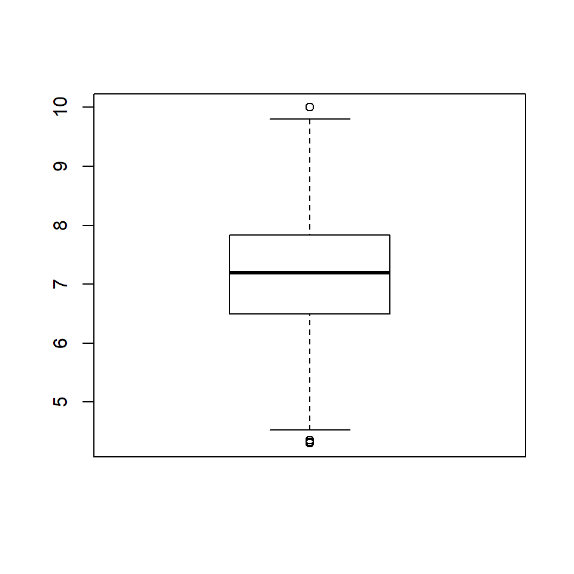

```r
boxplot(datF$english_score)
```

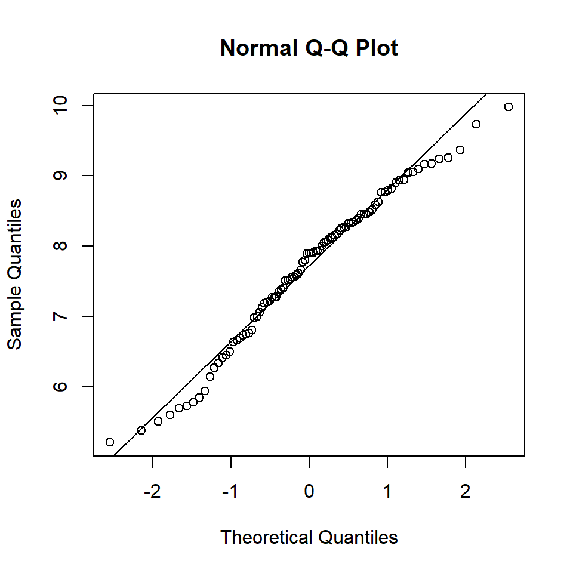

```r
qqnorm(datM$english_score)
qqline(datM$english_score)
```

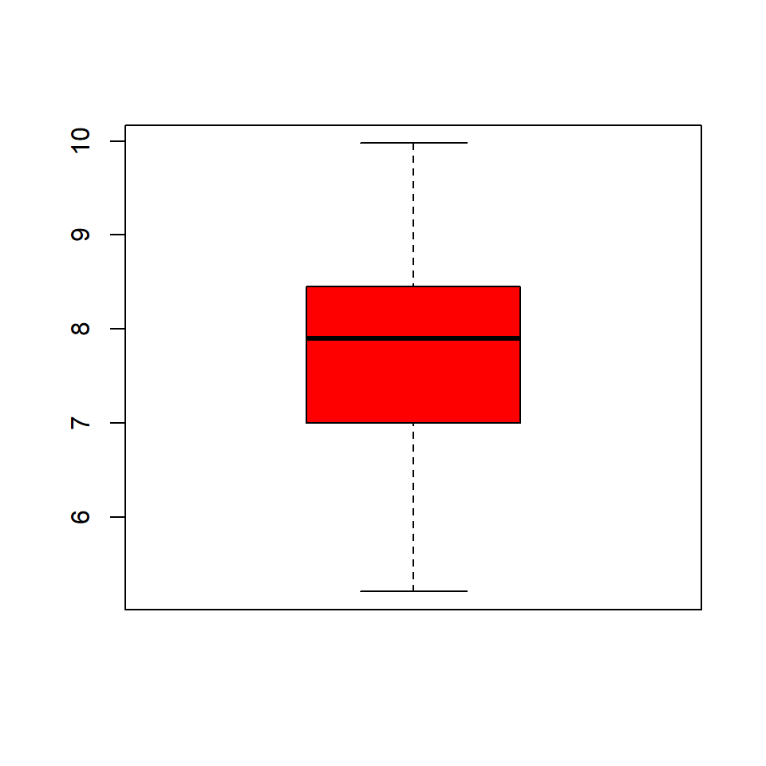

```r
boxplot(datM$english_score, col="red")
```

```r
t.test(datF$english_score, datM$english_score)
```

```
##
##  Welch Two Sample t-test
##
## data:  datF$english_score and datM$english_score
## t = -3.6046, df = 181.12, p-value = 0.000404
## alternative hypothesis: true difference in means is not equal to 0
## 95 percent confidence interval:
##  -0.7515075 -0.2198090
## sample estimates:
## mean of x mean of y
##  7.203624  7.689283
```

```r
library(effsize)
cohen.d(datF$english_score, datM$english_score)
```

```
##
## Cohen's d
##
## d estimate: -0.4358338 (small)
## 95 percent confidence interval:
##        inf        sup
## -0.6812580 -0.1904097
```

We obtained English scores in a sample of 315 students of the Statistiek 1 course via an online questionnaire(222F, 93M).

H0: $\mu$F = $\mu$M Ha: $\mu$F $\neq$ $\mu$M This hypothesis is tested with a two-sided T-test Significance level: = 0.05 p = 0.0004

The p-level is below the significance level. Therefor we must reject H0 and accept Ha.

Cohen’s d: -0.4358338 (small) Mean english_score females: 7.203624 Mean english_score males 7.689283. Significance level: 0.05:

The effectsize is small, so it isn’t worth mentioning.

# 4 Exercise 4

```r
table(dat$study)
```

```
##
##   CIS    IS  LING OTHER
##   101    74   102    38
```

```r
datC <- dat[dat$study == "CIS", ]
datL <- dat[dat$study == "LING", ]
mean(datC$english_score)
```

```
## [1] 7.177996
```

```r
mean(datL$english_score)
```

```
## [1] 7.106976
```

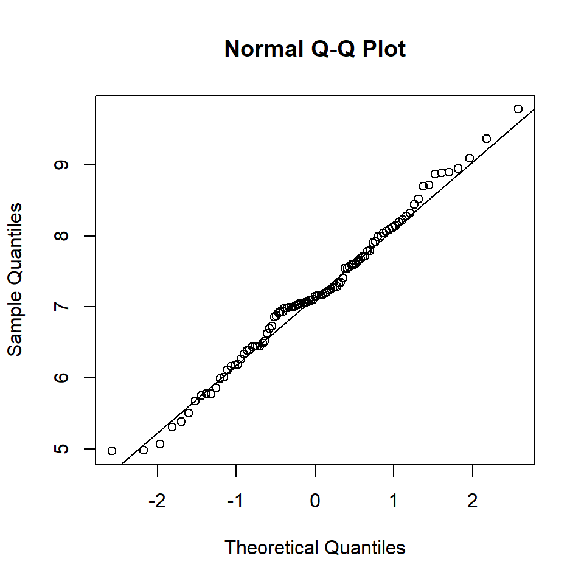

```r
qqnorm(datC$english_score)
qqline(datC$english_score)
```

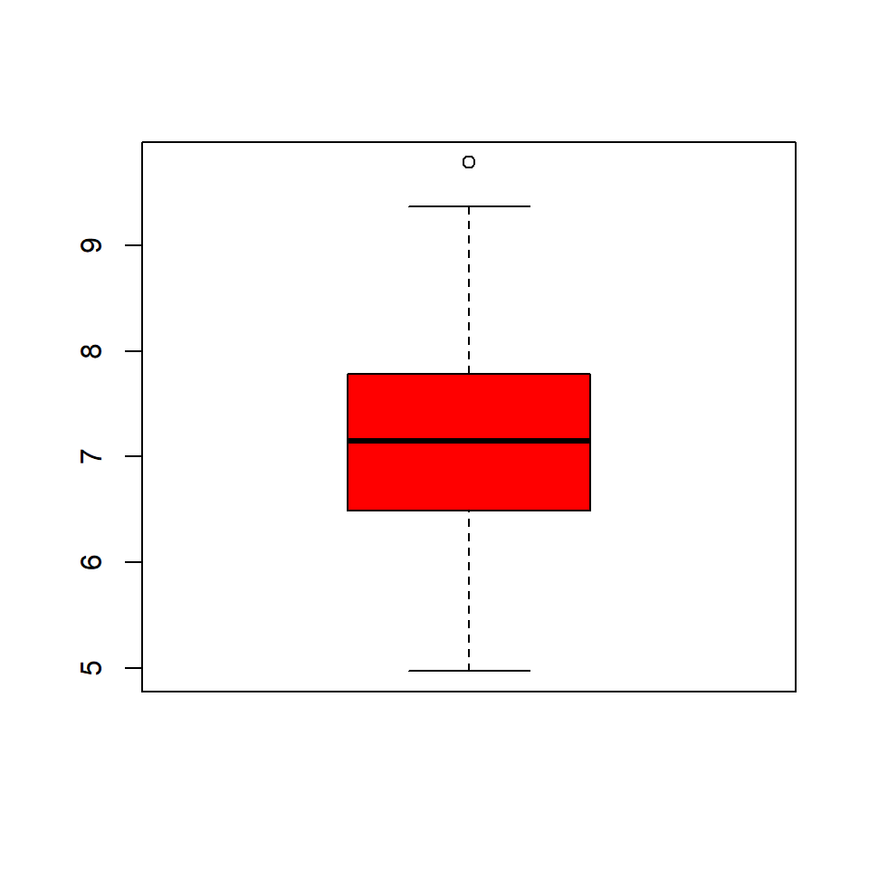

```r
boxplot(datC$english_score, col="red")
```

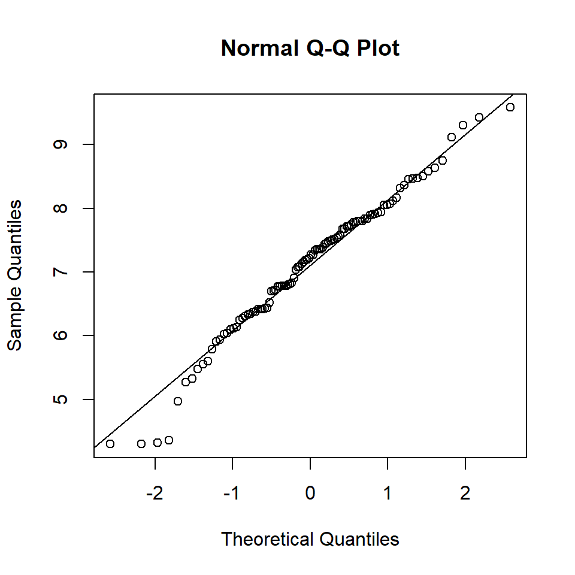

```r
qqnorm(datL$english_score)
qqline(datL$english_score)
```

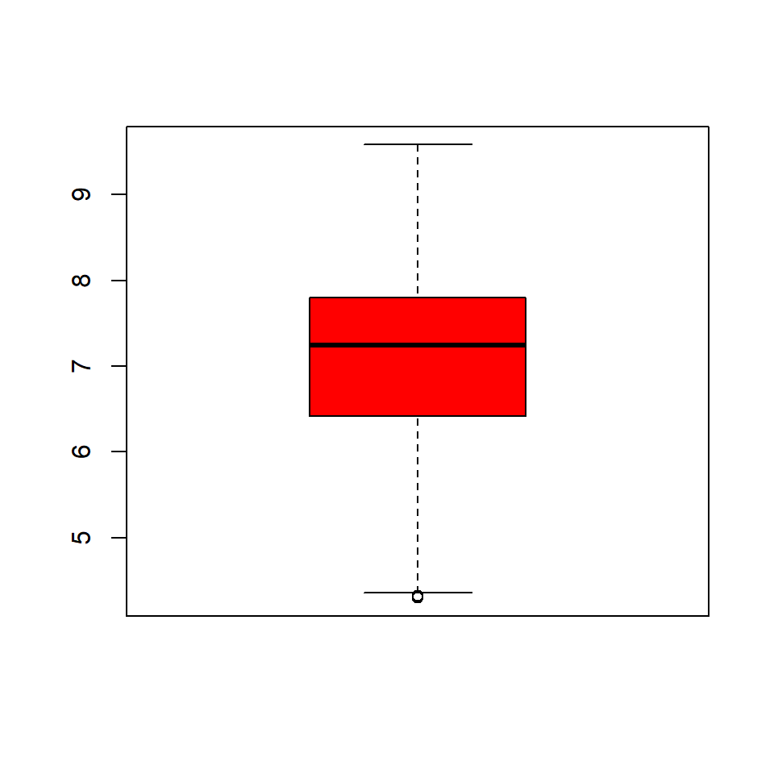

```r
boxplot(datL$english_score, col="red")
```

```r
t.test(datC$english_score, datL$english_score)
```

```
##
##  Welch Two Sample t-test
##
## data:  datC$english_score and datL$english_score
## t = 0.48587, df = 199.23, p-value = 0.6276
## alternative hypothesis: true difference in means is not equal to 0
## 95 percent confidence interval:
##  -0.2172196  0.3592604
## sample estimates:
## mean of x mean of y
##  7.177996  7.106976
```

```r
cohen.d(datC$english_score,datL$english_score)
```

```
##
## Cohen's d
##
## d estimate: 0.06816897 (negligible)
## 95 percent confidence interval:
##        inf        sup
## -0.2087064  0.3450443
```

H0: English scores from CIS students are higher than Ling students. Ha: English scores from CIS students are not higher than Ling students.

H0: $\mu$C = $\mu$L Ha: $\mu$C $\neq$ $\mu$L This hypothesis is tested with a two-sided T-test Significance level: 0.05 t(199) = 0.49 p = 0.63

The p-level is higher than the significance level. Therefor H0 will not be rejected.

Cohen’s d estimate: 0.06816897 (negligible) Mean english_score CIS: 7.177996 Mean english_score LING 7.106976. Significance level: 0.05

The effectsize is negligible and there for there isn’t much effect.

# 5 Exercise 5

```r
datM <- dat[dat$gender == "M", ]
mean(datM$english_grade)
```

```
## [1] 7.635484
```

```r
mean(datM$english_score)
```

```
## [1] 7.689283
```

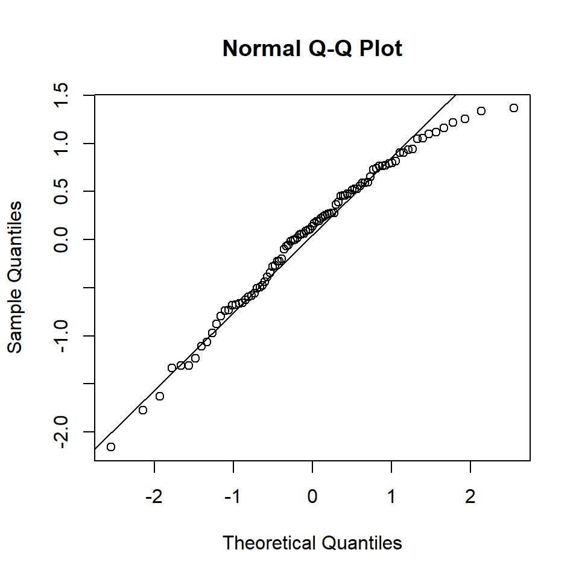

```r
qqnorm(datM$english_score-datM$english_grade)
qqline(datM$english_score-datM$english_grade)
```

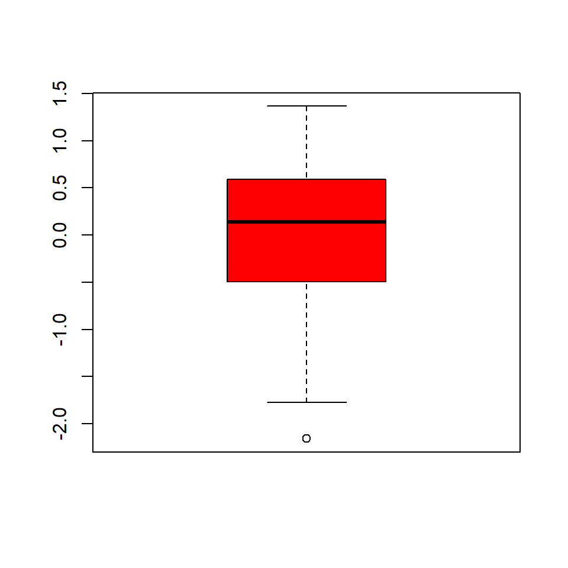

```r
boxplot(datM$english_score-datM$english_grade, col="red")
```

```r
t.test(datM$english_score, datM$english_grade, alternative = "greater", paired = TRUE)
```

```
##
##  Paired t-test
##
## data:  datM$english_score and datM$english_grade
## t = 0.684, df = 92, p-value = 0.2478
## alternative hypothesis: true difference in means is greater than 0
## 95 percent confidence interval:
##  -0.07689089         Inf
## sample estimates:
## mean of the differences
##              0.05379869
```

```r
cohen.d(datM$english_score, datM$english_grade, paired = T)
```

```
##
## Cohen's d
##
## d estimate: 0.07092706 (negligible)
## 95 percent confidence interval:
##        inf        sup
## -0.2184899  0.3603441
```

H0: English scores of men are significantly equal to their English grades. Ha: English scores of men are significantly higher than the English grades.

we are interested in assessing if for H0: $\mu$S = $\mu$G Ha: $\mu$S > $\mu$G This hypothesis is tested with a one-sided T-test. Significance level: 0.05: p = 0.2478

The p-level is higher than the significance level. Therefor we do not reject H0.

The effectsize is neglible and therefor not important.

# 6 Exercise 6

```r
datM <- dat[dat$gender == "M", ]
dat17 <- datM[datM$year == "2017", ]
mean(dat17$english_grade)
```

```
## [1] 7.713514
```

```r
mean(dat17$english_score)
```

```
## [1] 7.895873
```

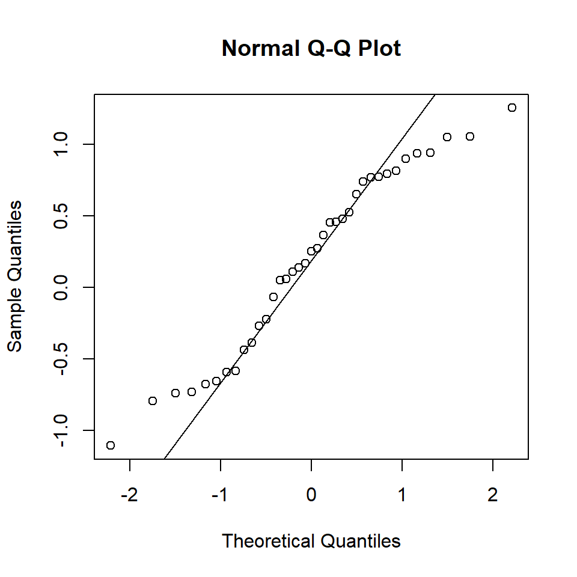

```r
qqnorm(dat17$english_score-dat17$english_grade)
qqline(dat17$english_score-dat17$english_grade)
```

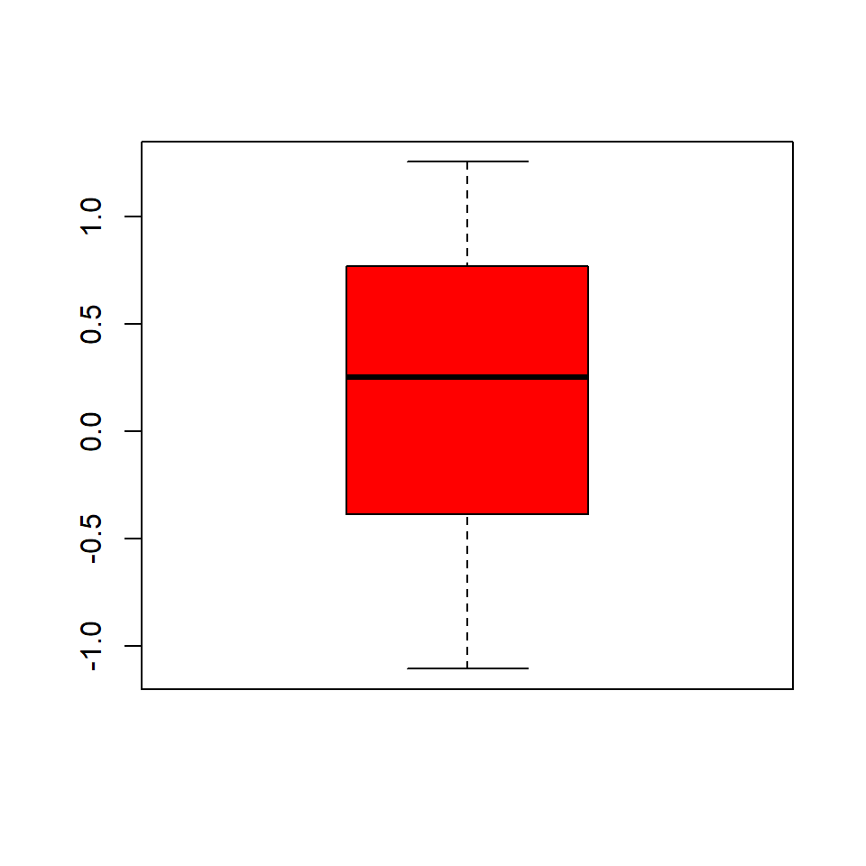

```r
boxplot(dat17$english_score-dat17$english_grade, col="red")
```

```r
t.test(dat17$english_score, dat17$english_grade, alternative = "greater", paired = TRUE)
```

```
##
##  Paired t-test
##
## data:  dat17$english_score and dat17$english_grade
## t = 1.726, df = 36, p-value = 0.04646
## alternative hypothesis: true difference in means is greater than 0
## 95 percent confidence interval:
##  0.00398362        Inf
## sample estimates:
## mean of the differences
##               0.1823596
```

```r
cohen.d(dat17$english_score, dat17$english_grade, paired = TRUE)
```

```
##
## Cohen's d
##
## d estimate: 0.283753 (small)
## 95 percent confidence interval:
##        inf        sup
## -0.1820443  0.7495503
```

H0: The English scores of men with the academic year of 2017 are equal than their English grades. Ha: The English scores of men with the academic year of 2017 are significantly higher than their English grades.

H0: $\mu$S = $\mu$G Ha: $\mu$S > $\mu$G

This hypothesis is tested with a paired T-test. Significance level: 0.05: p = 0.04646

The p-level is lower than the significance level. Therefor we must reject H0 and accept Ha.

Cohen’s d estimate: 0.283753 (small) Mean english_grade: 7.713514 Mean english_score: 7.895873. Significance level: 0.05:

The effectsize is small and therefor not important.